# Final Project slides

### Introduction

In this presentation, we will be using a County Dataset (project_177.csv) for the purpose of analyzing the majority of Democrat or Republican votes in the 2016 presidential election by county, which is a two-level categorical y-variable. In the 2016 presidential election, the Democratic Party nominee was Hillary Clinton and the Republican Party nominee was Donald Trump.

While the former won the popular vote, the latter won the Electoral College (and therefore the presidency). The purpose of this presentation is to investigate whether socioeconomic trends, patterns, etc. contribute to counties either leaning/voting Democrat or Republican in the 2016 presidential election, and how strong the relationship between these predictor variables and the y-variable (Election Results in 2016) is through various methods.

### Goals for this Project

My goals for this project:

- Learn about which socioeconomic factors are correlated with a county voting Democratic or Republican.
- Apply data visualization techniques and statistical concepts to understanding the relationship between continuous and categorical variables in this dataset.
- Extrapolate based on trends and patterns that are observed when analyzing and maninpulating data so that predictions can be made about future elections, such as in 2020, between the Democratic nominee (Joe Biden) and the Republican nominee (Donald Trump).

### Questions About the Dataset

Some questions I had about the dataset in terms of the y-variable I chose (Election Results in 2016, Democrat or Republican) included:

- Which socioeconomic factors are strongly correlated with whether a county voted Democratic or Republican?
- Is there a statistically significant difference in predictor (x) variables such as unemployment, median household income, high school graduation rate, etc. between counties that voted Democratic and those that voted Republican?
- Does this data help confirm many Americans' assumptions about how socioeconomic differences tend to push groups of people (in this case, counties) toward one political party or the other?

### Downloading, Reading in, and Reviewing the Data (Current and Next Two Slides)

```python
import numpy as np
import pandas as pd
import matplotlib.pyplot as plt
import seaborn as sns
import os
import statsmodels.api as sm
import statsmodels.formula.api as smf
import math
from statsmodels.graphics.mosaicplot import mosaic
from sklearn import tree
from sklearn.model_selection import train_test_split
```

```python
os.chdir("/Users/keshavramesh/Downloads/Programming Languages/Python/Final Project/")
county_data = pd.read_csv("project_177.csv")
index_col = 0
print(county_data.info())
```

```
<class 'pandas.core.frame.DataFrame'>
RangeIndex: 2715 entries, 0 to 2714
Data columns (total 27 columns):
 #   Column                            Non-Null Count  Dtype
---  ------                            --------------  -----
 0   Row.Label                         2715 non-null   object
 1   Five-digit.FIPS.Code              2715 non-null   int64
 2   State.FIPS.Code                   2715 non-null   int64
 3   County.FIPS.Code                  2715 non-null   int64
 4   State.Abbreviation                2715 non-null   object
 5   CountyName                        2715 non-null   object
 6   Poor.Health                       2715 non-null   float64
 7   Election.Results.2016             2715 non-null   object
 8   Uninsured                         2715 non-null   float64
 9   Primary.Care.Physicians.Per.1000  2715 non-null   float64
```

[output cut: 20 more lines]

```python
print(county_data.head(3))
```

```
           Row.Label  Five-digit.FIPS.Code  State.FIPS.Code  County.FIPS.Code  \
0  AL_Autauga County                  1001                1                 1
1  AL_Baldwin County                  1003                1                 3
2  AL_Barbour County                  1005                1                 5

  State.Abbreviation      CountyName  Poor.Health Election.Results.2016  \
0                 AL  Autauga County       0.1841            Republican
1                 AL  Baldwin County       0.1806            Republican
2                 AL  Barbour County       0.2577            Republican

   Uninsured  Primary.Care.Physicians.Per.1000  ...  Median.Household.Income  \
0     0.0850                             0.415  ...                    58343
1     0.1070                             0.729  ...                    56607
2     0.1251                             0.385  ...                    32490

   Severe.Housing.Problems  Unemployment  Food.Insecurity.Quintile  \
0                   0.1495        0.0386                        Q3
1                   0.1383        0.0399                        Q3
2                   0.1546        0.0590                        Q5

   Income.Inequality.Quartile  Percent.Rural  Over.65  Percent.Females  \
0                          Q3         0.4200    0.151            0.513
1                          Q3         0.4228    0.199            0.515
2                          Q4         0.6779    0.188            0.472

   Life.Expectancy  Population
0        76.330589       55504
1        78.599498      212628
2        75.779457       25270

[3 rows x 27 columns]
```

### Boxplot/Violin Plot of County Election Results in 2016 over Median Household Income

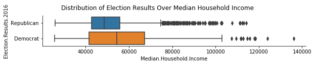

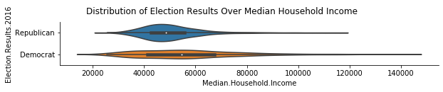

```python
a1 = sns.catplot(x = "Median.Household.Income", y = "Election.Results.2016", kind = "box", data = county_data, height = 1.75, aspect = 5, orient = "h")
a1.fig.suptitle("Distribution of Election Results Over Median Household Income")

a2 = sns.catplot(x = "Median.Household.Income", y = "Election.Results.2016", kind = "violin", data = county_data, height = 1.75, aspect = 5, orient = "h")
a2.fig.suptitle("Distribution of Election Results Over Median Household Income")
```

### Two-Sample Hypothesis t-Test for Equality of Means in terms of Median Household Income (Sub-Slide Below)

Here, we calculate the average value for median household income for Democrats and Republicans across all counties, as well as the median value for the median household income for Democrats and Republicans across all counties. In both scenarios, we find that Democrats have a higher median value for median household income and average value for median household income than Republicans.

Then, we conduct a two-sample t-test for equality of means and find that the probability that the p-value is greater than t is less than 0.05, so we can reject the null hypothesis and conclude that there is a statistically significant difference between the mean value for median household income for Democrats (which was calculated as 57,005.876682) and the mean value for median household income for Republicans (which was calculated as 50,545.254297).

```python
# Calculate the average value for Median Household Income for Democrats and Republicans across all counties
print(county_data.groupby("Election.Results.2016")["Median.Household.Income"].mean())

# Calculate the median value for Median Household Income for Democrats and Republicans across all counties
print(county_data.groupby("Election.Results.2016")["Median.Household.Income"].median())

# Two-Sample t-test for equality of means
x1 = sm.stats.DescrStatsW(county_data["Median.Household.Income"].loc[county_data["Election.Results.2016"] == "Democrat"])
x2 = sm.stats.DescrStatsW(county_data["Median.Household.Income"].loc[county_data["Election.Results.2016"] == "Republican"])
comp_means = sm.stats.CompareMeans(x1, x2)
comp_means.summary(usevar = "unequal")
```

```
Election.Results.2016
Democrat      57005.876682
Republican    50545.254297
Name: Median.Household.Income, dtype: float64
Election.Results.2016
Democrat      54525.5
Republican    48581.0
Name: Median.Household.Income, dtype: float64
```

Test for equality of means

|  | coef | std err | t | P>\|t\| | [0.025 | 0.975] |
| --- | --- | --- | --- | --- | --- | --- |
| subset #1 | 6460.6224 | 965.904 | 6.689 | 0.000 | 4562.978 | 8358.266 |

### Two-Sample Hypothesis t-Test for Equality of Means in terms of Unemployment Rate (Sub-Slide Below)

Then, we conduct a two-sample t-test for equality of means and find that the probability that the p-value is greater than t is less than 0.05, so we can reject the null hypothesis and conclude that there is a statistically significant difference between the mean value for unemployment rate for Democrats (which was calculated as 0.048868, or 4.8868%) and the mean value for unemployment rate for Republicans (which was calculated as 0.045555, or 4.5555%).

```python
# Calculate the average value for the Unemployment Rate for Democrats and Republicans across all counties
print(county_data.groupby("Election.Results.2016")["Unemployment"].mean())

# Calculate the median value for the Unemployment Rate for Democrats and Republicans across all counties
print(county_data.groupby("Election.Results.2016")["Unemployment"].median())

# Two-Sample t-test for equality of means
x3 = sm.stats.DescrStatsW(county_data["Unemployment"].loc[county_data["Election.Results.2016"] == "Democrat"])
x4 = sm.stats.DescrStatsW(county_data["Unemployment"].loc[county_data["Election.Results.2016"] == "Republican"])
comp_means = sm.stats.CompareMeans(x3, x4)
comp_means.summary(usevar = "unequal")
```

```
Election.Results.2016
Democrat      0.048868
Republican    0.045555
Name: Unemployment, dtype: float64
Election.Results.2016
Democrat      0.0451
Republican    0.0436
Name: Unemployment, dtype: float64
```

Test for equality of means

|  | coef | std err | t | P>\|t\| | [0.025 | 0.975] |
| --- | --- | --- | --- | --- | --- | --- |
| subset #1 | 0.0033 | 0.001 | 3.448 | 0.001 | 0.001 | 0.005 |

### Two-Sample Hypothesis t-Test for Equality of Means in terms of High School Graduation Rate (Sub-Slide Below)

Then, we conduct a two-sample t-test for equality of means and find that the probability that the p-value is greater than t is less than 0.05, so we can reject the null hypothesis and conclude that there is a statistically significant difference between the mean value for high school graduation rate for Democrats (which was calculated as 0.847371, or 84.7371%) and the mean value for high school graduation rate for Republicans (which was calculated as 0.889883, or 88.9883%).

```python
# Calculate the average value for the High School Graduation Rate for Democrats and Republicans across all counties
print(county_data.groupby("Election.Results.2016")["High.School.Graduation"].mean())

# Calculate the median value for the High School Graduation Rate for Democrats and Republicans across all counties
print(county_data.groupby("Election.Results.2016")["High.School.Graduation"].median())

# Two-Sample t-test for equality of means
x5 = sm.stats.DescrStatsW(county_data["High.School.Graduation"].loc[county_data["Election.Results.2016"] == "Democrat"])
x6 = sm.stats.DescrStatsW(county_data["High.School.Graduation"].loc[county_data["Election.Results.2016"] == "Republican"])
comp_means = sm.stats.CompareMeans(x5, x6)
comp_means.summary(usevar = "unequal")
```

```
Election.Results.2016
Democrat      0.847371
Republican    0.889883
Name: High.School.Graduation, dtype: float64
Election.Results.2016
Democrat      0.8619
Republican    0.9018
Name: High.School.Graduation, dtype: float64
```

Test for equality of means

|  | coef | std err | t | P>\|t\| | [0.025 | 0.975] |
| --- | --- | --- | --- | --- | --- | --- |
| subset #1 | -0.0425 | 0.004 | -10.947 | 0.000 | -0.050 | -0.035 |

### Box Plot and Bar Chart Distributions for Income Inequality (Next Two Slides)

The below box plots and bar charts constructed measure the distribution of county Democrat/Republican election results in 2016 (categorical y-variable) over median household income (continuous x-variable) and separated by income inequality quartiles.

Observe that in both the box plot and bar chart constructed below, counties in highest quartile (Q1 or top 25%) for income inequality (meaning that they have the least income inequality) have the highest median household income out of all of the income inequality quartiles for both Democrat-voting counties and Republican-voting counties.

Additionally, observe that in both the box plot and bar chart constructed below, counties in lowest quartile (Q4 or bottom 25%) for income inequality (meaning that they have the most income inequality) have the lowest median household income out of all of the income inequality quartiles for both Democrat-voting counties and Republican-voting counties.

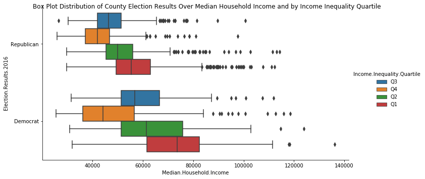

```python
b1 = sns.catplot(x = "Median.Household.Income", y = "Election.Results.2016", hue = "Income.Inequality.Quartile", kind = "box", data = county_data, height = 5, aspect = 2);
b1.fig.suptitle("Box Plot Distribution of County Election Results Over Median Household Income and by Income Inequality Quartile")
```

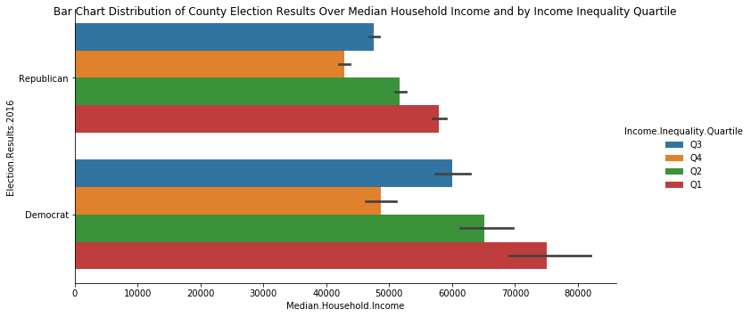

```python
b2 = sns.catplot(x = "Median.Household.Income", y = "Election.Results.2016", hue = "Income.Inequality.Quartile", kind = "bar", data = county_data, height = 5, aspect = 2)
b2.fig.suptitle("Bar Chart Distribution of County Election Results Over Median Household Income and by Income Inequality Quartile")
```

### Box Plot and Bar Chart Distributions for Food Insecurity (Next Two Slides)

The below box plot and bar chart constructed measure the distribution of county Democrat/Republican election results in 2016 (categorical y-variable) over median household income (continuous x-variable) and separated by food insecurity quintiles.

Observe that in both the box plot and bar chart constructed below, counties in highest quintile (Q1 or top 20%) for food insecurity (meaning that they have the most food security) have the highest median household income out of all of the food insecurity quintiles for both Democrat-voting counties and Republican-voting counties.

Additionally, observe that in both the box plot and bar chart constructed below, counties in lowest quintile (Q5 or bottom 20%) for food insecurity (meaning that they have the least food security) have the lowest median household income out of all of the food insecurity quintiles for both Democrat-voting counties and Republican-voting counties.

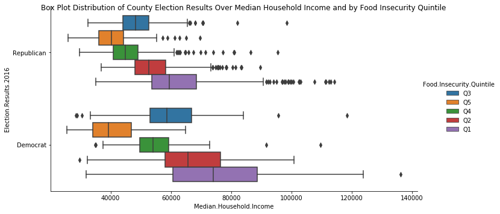

```python
c1 = sns.catplot(x = "Median.Household.Income", y = "Election.Results.2016", hue = "Food.Insecurity.Quintile", kind = "box", data = county_data, height = 5, aspect = 2);
c1.fig.suptitle("Box Plot Distribution of County Election Results Over Median Household Income and by Food Insecurity Quintile")
```

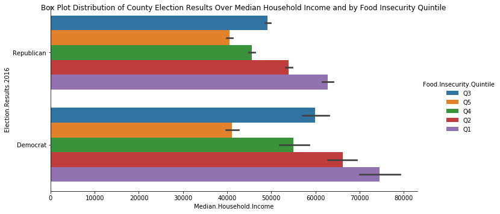

```python
c1 = sns.catplot(x = "Median.Household.Income", y = "Election.Results.2016", hue = "Food.Insecurity.Quintile", kind = "bar", data = county_data, height = 5, aspect = 2);
c1.fig.suptitle("Box Plot Distribution of County Election Results Over Median Household Income and by Food Insecurity Quintile")
```

### Simple Regression of Rate of Severe Housing Problems vs. High School Graduation Rate (Sub-Slide Below)

From the scatterplot, we can observe that there is a weak, negative correlation between counties' rate of severe housing problems and their high school graduation rate across the United States, with a cluster of values between high school graduation rates of 0.7 and 1.0, and some outliers to the left of that cluster.

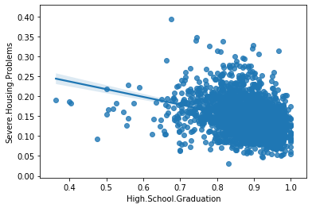

```python
# Simple regression of Rate of Severe Housing Problems vs. High School Graduation Rate using Seaborn's regplot
sns.regplot(x = "High.School.Graduation", y = "Severe.Housing.Problems", data = county_data)
```

### Color-Coded Scatterplot of Rate of Severe Housing Problems vs. High School Graduation Rate (Sub-Slide Below)

From the scatterplot, we can observe that clusters of Democrat counties (designated as orange) can be found at higher rates of severe housing problems than clusters of Republican counties (designated as blue).

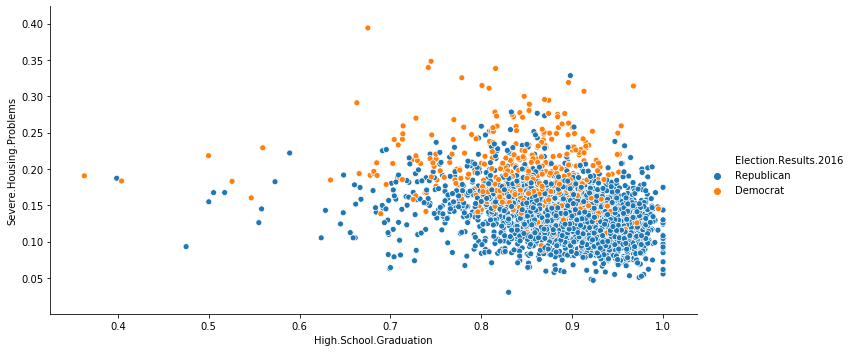

```python
# Color-coded scatterplot of Rate of Severe Housing Problems vs. High School Graduation Rate using a hue based on Election Results in 2016 and Seaborn's relplot
sns.relplot(x = "High.School.Graduation", y = "Severe.Housing.Problems", hue = "Election.Results.2016", data = county_data, height = 5, aspect = 2)
```

### Simple Regression on Color-Coded Scatterplot of Rate of Severe Housing Problems vs. High School Graduation Rate (Sub-Slide Below)

From the scatterplot, we can observe that clusters of Democrat counties (designated as orange dots) can be found at higher rates of severe housing problems than clusters of Republican counties (designated as blue "x" marks). Additionally, there is a very weak, negative correlation between the rate of severe housing problems and high school graduation rate for Democrat counties, while there is a relatively stronger but still weak, negative correlation between the rate of severe housing problems and high school graduation rate for Republican counties. Both Democrat and Republican counties have outliers to the left of their respective clusters within the data.

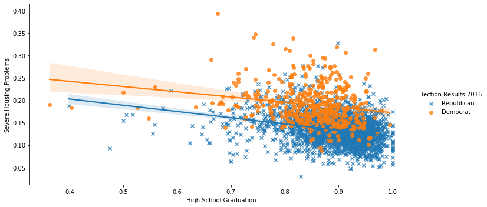

```python
# Simple regression on color-coded scatterplot of Rate of Severe Housing Problems vs. High School Graduation Rate using a hue based on Election Results in 2016 and Seaborn's lmplot
sns.lmplot(x = "High.School.Graduation", y = "Severe.Housing.Problems", hue = "Election.Results.2016", data = county_data, markers = ["x", "o"], height = 5, aspect = 2)
```

### Fitting Simple Regression Model (Sub-Slide Below)

Observations:

- The R-squared value, 0.240, means that approximately 24.0% of the data fits the simple regression model.
- The x-variable "Over.65" is an important predictor of y-variable "Percent.Rural" because it is statistically significant (since the p-value is less than 0.05).
- Using a 95% confidence interval, the margin of error predicton would be approximately +/-0.530977.

```python
olsmod1 = smf.ols(formula = "Q('Percent.Rural') ~ Q('Over.65')", data = county_data)
olsres1 = olsmod1.fit()
print(olsres1.summary())

# Creating new data frame for prediction
Xnew = {"Over.65": [0.15, 0.2]}
print(olsres1.predict(Xnew))
math.sqrt(olsres1.mse_resid)

# 95% confidence interval for margin of error predictions
print("+/-" + str(2 * (math.sqrt(olsres1.mse_resid))))
```

```
                            OLS Regression Results
==============================================================================
Dep. Variable:     Q('Percent.Rural')   R-squared:                       0.240
Model:                            OLS   Adj. R-squared:                  0.240
Method:                 Least Squares   F-statistic:                     858.0
Date:                Wed, 12 Aug 2020   Prob (F-statistic):          4.13e-164
Time:                        20:26:58   Log-Likelihood:                -250.83
No. Observations:                2715   AIC:                             505.7
Df Residuals:                    2713   BIC:                             517.5
Df Model:                           1
Covariance Type:            nonrobust
================================================================================
                   coef    std err          t      P>|t|      [0.025      0.975]
--------------------------------------------------------------------------------
Intercept       -0.0779      0.022     -3.572      0.000      -0.121      -0.035
Q('Over.65')     3.3452      0.114     29.291      0.000       3.121       3.569
==============================================================================
Omnibus:                       12.177   Durbin-Watson:                   1.586
Prob(Omnibus):                  0.002   Jarque-Bera (JB):               12.501
Skew:                          -0.140   Prob(JB):                      0.00193
Kurtosis:                       3.179   Cond. No.                         23.2
==============================================================================

Warnings:
[1] Standard Errors assume that the covariance matrix of the errors is correctly specified.
0    0.423866
1    0.591128
dtype: float64
+/-0.5309765930074052
```

## Fitting Parallel Lines Regression Model (Sub-Slide Below)

Observations:

- The R-squared value, 0.302, means that approximately 30.2% of the data fits the parallel lines regression model.
- There is statistical significance because the p-value is less than 0.05.

```python
print(pd.get_dummies(data = county_data["Election.Results.2016"]))

olsmod2 = smf.ols(formula = "Q('Percent.Rural') ~ Q('Over.65') + Q('Election.Results.2016')", data = county_data)
olsres2 = olsmod2.fit()
print(olsres2.summary())
```

```
      Democrat  Republican
0            0           1
1            0           1
2            0           1
3            0           1
4            0           1
...        ...         ...
2710         0           1
2711         0           1
2712         0           1
2713         0           1
2714         0           1

[2715 rows x 2 columns]
                            OLS Regression Results
==============================================================================
Dep. Variable:     Q('Percent.Rural')   R-squared:                       0.302
Model:                            OLS   Adj. R-squared:                  0.302
Method:                 Least Squares   F-statistic:                     587.1
Date:                Wed, 12 Aug 2020   Prob (F-statistic):          1.40e-212
Time:                        20:26:58   Log-Likelihood:                -135.49
No. Observations:                2715   AIC:                             277.0
Df Residuals:                    2712   BIC:                             294.7
Df Model:                           2
Covariance Type:            nonrobust
============================================================================================================
                                               coef    std err          t      P>|t|      [0.025      0.975]
------------------------------------------------------------------------------------------------------------
Intercept                                   -0.1723      0.022     -7.912      0.000      -0.215      -0.130
Q('Election.Results.2016')[T.Republican]     0.2113      0.014     15.508      0.000       0.185       0.238
Q('Over.65')                                 2.9028      0.113     25.658      0.000       2.681       3.125
==============================================================================
Omnibus:                        9.852   Durbin-Watson:                   1.663
Prob(Omnibus):                  0.007   Jarque-Bera (JB):               12.538
Skew:                          -0.017   Prob(JB):                      0.00189
Kurtosis:                       3.331   Cond. No.                         31.4
==============================================================================

Warnings:
[1] Standard Errors assume that the covariance matrix of the errors is correctly specified.
```

### Fitting Interaction Model (Sub-Slide Below)

```python
olsmod3 = smf.ols(formula = "Q('Over.65') ~ Q('Election.Results.2016') + Q('Over.65'):Q('Election.Results.2016')", data = county_data)
olsres3 = olsmod3.fit()
print(olsres3.summary())
```

```
                            OLS Regression Results
==============================================================================
Dep. Variable:           Q('Over.65')   R-squared:                       1.000
Model:                            OLS   Adj. R-squared:                  1.000
Method:                 Least Squares   F-statistic:                 8.678e+31
Date:                Wed, 12 Aug 2020   Prob (F-statistic):               0.00
Time:                        20:26:58   Log-Likelihood:                 95182.
No. Observations:                2715   AIC:                        -1.904e+05
Df Residuals:                    2711   BIC:                        -1.903e+05
Df Model:                           3
Covariance Type:            nonrobust
=======================================================================================================================
                                                          coef    std err          t      P>|t|      [0.025      0.975]
-----------------------------------------------------------------------------------------------------------------------
Intercept                                           -2.056e-16   2.86e-17     -7.195      0.000   -2.62e-16    -1.5e-16
Q('Election.Results.2016')[T.Republican]             5.204e-18   3.16e-17      0.165      0.869   -5.68e-17    6.72e-17
Q('Over.65'):Q('Election.Results.2016')[Democrat]       1.0000   1.73e-16   5.78e+15      0.000       1.000       1.000
Q('Over.65'):Q('Election.Results.2016')[Republican]     1.0000   6.89e-17   1.45e+16      0.000       1.000       1.000
==============================================================================
Omnibus:                     1062.971   Durbin-Watson:                   0.238
Prob(Omnibus):                  0.000   Jarque-Bera (JB):             3324.308
Skew:                          -2.062   Prob(JB):                         0.00
Kurtosis:                       6.519   Cond. No.                         85.8
==============================================================================

Warnings:
[1] Standard Errors assume that the covariance matrix of the errors is correctly specified.
```

### Constructing Mosaic Plot of County Election Results in 2016 by Population (Sub-Slide Below)

The mosaic plot shows that population brackets consisting of counties with higher populations have a higher proportion of Democrat-voting counties, while population brackets consisting of counties with lower populations have a higher proportion of Republican-voting counties.

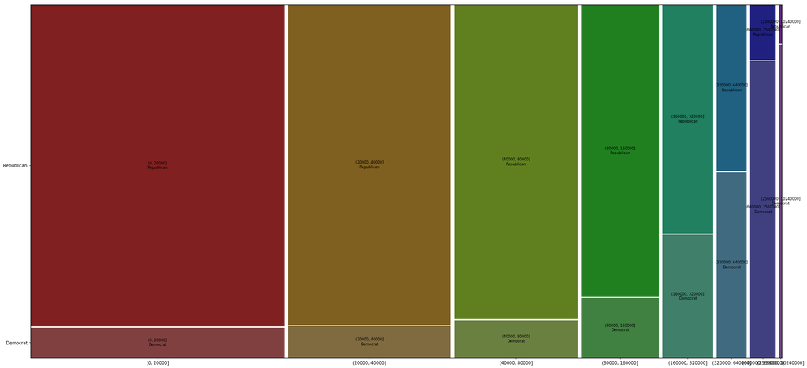

```python
county_data["Population_Bracket"] = pd.cut(county_data["Population"], [0, 20000, 40000, 80000, 160000, 320000, 640000, 2560000, 10240000])
fig, ax1 = plt.subplots(figsize = (31, 15))
mosaic(county_data, ["Population_Bracket", "Election.Results.2016"], ax = ax1);
```

### Creating a Decision Tree

The following code involves building a decision tree for 2016 Election Results. Variables to be used as potential predictors:

```
[Row.Label, Five-digit.FIPS.Code, State.FIPS.Code, County.FIPS.Code, State.Abbreviation, CountyName, Poor.Health, Uninsured, Primary.Care.Physicians.Per.1000, Mental.health.providers.Per.1000, Adult.Obesity, Proportion.of.Smokers, High.School.Graduation, Insufficient.Sleep, Physical.Inactivity, Excessive.Drinking, Median.Household.Income, Severe.Housing.Problems, Unemployment, Food.Insecurity.Quintile, Income.Inequality.Quartile, Percent.Rural, Over.65,
Percent.Females, Life.Expectancy, Population]
```

Steps taken for creating the decision tree:

- Created version of data frame with continuous variables ("Xcts") and one with categorical variables ("Xcat").
- Binarized categorical variables with pandas "pd.get_dummies" function and "drop_first = True" argument.
- Merged continuous and binarized categorical variables into combined data.
- Trained and tested data, then created decision tree based on Election Results in 2016 (categorical variable).

```python
Xcts = county_data[["Five-digit.FIPS.Code", "County.FIPS.Code", "Poor.Health", "Uninsured", "Primary.Care.Physicians.Per.1000", "Mental.health.providers.Per.1000", "Adult.Obesity", "Proportion.of.Smokers", "High.School.Graduation", "Insufficient.Sleep", "Physical.Inactivity", "Excessive.Drinking", "Median.Household.Income", "Severe.Housing.Problems", "Unemployment", "Percent.Rural", "Over.65", "Percent.Females", "Life.Expectancy", "Population"]]
Xcat = pd.get_dummies(county_data[["Row.Label", "State.Abbreviation", "CountyName", "Food.Insecurity.Quintile", "Income.Inequality.Quartile"]], drop_first = True)
X = pd.merge(Xcts, Xcat, left_index = True, right_index = True)
print(X.shape)
y = county_data["Election.Results.2016"]
print(X.head(3))
```

```
(2715, 4445)
   Five-digit.FIPS.Code  County.FIPS.Code  Poor.Health  Uninsured  \
0                  1001                 1       0.1841     0.0850
1                  1003                 3       0.1806     0.1070
2                  1005                 5       0.2577     0.1251

   Primary.Care.Physicians.Per.1000  Mental.health.providers.Per.1000  \
0                             0.415                             0.162
1                             0.729                             0.912
2                             0.385                             0.079

   Adult.Obesity  Proportion.of.Smokers  High.School.Graduation  \
0          0.375               0.191247                  0.9000
1          0.310               0.167955                  0.8636
2          0.443               0.215394                  0.8141

   Insufficient.Sleep  ...  CountyName_Yuma County  CountyName_Zapata County  \
0              0.3591  ...                       0                         0
1              0.3331  ...                       0                         0
2              0.3856  ...                       0                         0

   CountyName_Zavala County  Food.Insecurity.Quintile_Q2  \
0                         0                            0
1                         0                            0
2                         0                            0

   Food.Insecurity.Quintile_Q3  Food.Insecurity.Quintile_Q4  \
0                            1                            0
1                            1                            0
2                            0                            0

   Food.Insecurity.Quintile_Q5  Income.Inequality.Quartile_Q2  \
0                            0                              0
1                            0                              0
2                            1                              0

   Income.Inequality.Quartile_Q3  Income.Inequality.Quartile_Q4
0                              1                              0
1                              1                              0
2                              0                              1

[3 rows x 4445 columns]
```

```python
# Training and testing the data using train_test_split
X_train, X_test, y_train, y_test = train_test_split(X, y, test_size = 0.5, random_state = 1)
print(X_train.shape)
print(X_test.shape)

# Decision tree created in sub-slide below
```

```
(1357, 4445)
(1358, 4445)
```

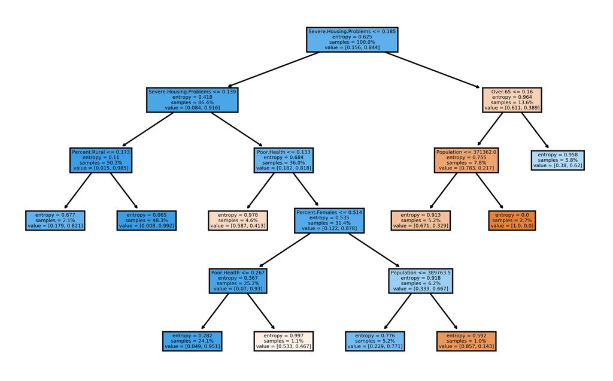

```python
regtree = tree.DecisionTreeClassifier(criterion = "entropy", max_leaf_nodes = 10, random_state = 0)
regtree = regtree.fit(X_train, y_train)
fig = plt.figure(num = None, figsize = (8, 5), dpi = 1000, facecolor = "w", edgecolor = "k")
tree.plot_tree(regtree, filled = True, feature_names = X.columns, proportion = True);
```

```python
%%javascript
$('.output_result').css('font-size', '2pt')
```